# Article Classification using the "20 Newsgroups" Data Set

```python
import numpy as np
import pandas as pd
import matplotlib.pyplot as plt
import seaborn as sns
import glob
import re
import nltk
from nltk.corpus import stopwords
import os

from sklearn.feature_extraction.text import CountVectorizer, TfidfVectorizer
from sklearn.metrics.pairwise import cosine_similarity
from sklearn.naive_bayes import MultinomialNB, ComplementNB
from sklearn.preprocessing import LabelEncoder
from sklearn.metrics import accuracy_score, confusion_matrix
from sklearn.cluster import AgglomerativeClustering
from sklearn.decomposition import PCA

from scipy.cluster.hierarchy import dendrogram, linkage

%matplotlib inline
```

```python
base_dir = 'H:\\Educational_Projects\\natural_language_processing\\'

train_raw = base_dir + 'data\\raw\\20news-bydate-train\\'
test_raw = base_dir + 'data\\raw\\20news-bydate-test\\'

train_clean = base_dir + 'data\\cleaned\\20news-bydate-train\\'
test_clean = base_dir + 'data\\cleaned\\20news-bydate-test\\'
```

## Text Cleaning

Text cleaning process:

- Convert characters to lowercase
- Restrict characters to common english alphabet (ignore numbers and unusual symbols)
- Remove excess whitespace
- Remove stop words
- Stem words (accounts for plurality)
- Format into a final "sentence"

```python
# Instantiate helpful classes (same for processing ALL articles)

# Porter stemmer
porter_stemmer = nltk.stem.porter.PorterStemmer()

# NLTK stopwords list
stop_words = set(stopwords.words('english'))

# Add individual letters to stop_words set
for each in u'abcdefghijklmnopqrstuvwxyz':
    stop_words.add(each)
```

### Training data

```python
# Setup data structure for corpus information
corpus = dict()
corpus['article_id'] = []
corpus['class'] = []
corpus['text'] = []

# Get article types
article_types = glob.glob(train_raw + '*')

# Iterate through article types
for article_type in article_types:

    # Print article category
    print article_type

    # Get articles
    article_list = glob.glob(article_type + '\\*')

    # Iterate through articles
    for article in article_list:

        # Open input file
        infile = open(article, 'r')

        # Create output directory if does not exist
        outdir = '\\'.join(article.replace('raw\\', 'cleaned\\', 1).split('\\')[:-1])
        if(not os.path.isdir(outdir)):
            os.makedirs(outdir)
            outfile = article.replace('raw\\', 'cleaned\\', 1)
        else:
            outfile = article.replace('raw\\', 'cleaned\\', 1)

        # Iterate through lines of file
        skip_flag = True
        tmp_words = []
        for line in infile:

            # Skip metadata lines until we encounter first whitespace
            # that separates metadata from article body
            if skip_flag == True:
                if line.strip() != '':
                    continue
                else:
                    skip_flag = False
                    continue

            # Convert all text to lower case for uniformity
            tmp_line = line.lower()

            # Replace all non-alphanumeric letters with spaces (should come before stemming)
            tmp_line = re.sub('[^a-zA-Z]+', ' ', tmp_line)

            # Split line into individual words
            tmp_words = tmp_words + tmp_line.strip().split()

        # Remove stopwords
        tmp_words = [word for word in tmp_words if not word in stop_words]

        # Stem words
        tmp_words = [porter_stemmer.stem(word) for word in tmp_words]

        # Add to corpus
        if(len(tmp_words) == 0):
            continue
        else:
            corpus['article_id'].append(article.split('\\')[-1])
            corpus['class'].append(article.split('\\')[-2])
            corpus['text'].append(' '.join(tmp_words))

        # Write words
        np.savetxt(outfile, tmp_words, fmt = '%s')

        # Close input file
        infile.close()

    # Moving to next article type

# Save cleaned corpus for future use
np.savetxt('\\'.join(article.replace('\\raw', '\\cleaned', 1).split('\\')[:-2]) + '\\train_ids.txt', corpus['article_id'], fmt = '%s')
np.savetxt('\\'.join(article.replace('\\raw', '\\cleaned', 1).split('\\')[:-2]) + '\\train_classes.txt', corpus['class'], fmt = '%s')
np.savetxt('\\'.join(article.replace('\\raw', '\\cleaned', 1).split('\\')[:-2]) + '\\train_text.txt', corpus['text'], fmt = '%s')

# End of processing
print 'Done'
```

```
H:\Educational_Projects\natural_language_processing\data\raw\20news-bydate-train\talk.religion.misc
H:\Educational_Projects\natural_language_processing\data\raw\20news-bydate-train\sci.crypt
H:\Educational_Projects\natural_language_processing\data\raw\20news-bydate-train\sci.space
H:\Educational_Projects\natural_language_processing\data\raw\20news-bydate-train\comp.os.ms-windows.misc
H:\Educational_Projects\natural_language_processing\data\raw\20news-bydate-train\misc.forsale
H:\Educational_Projects\natural_language_processing\data\raw\20news-bydate-train\sci.med
H:\Educational_Projects\natural_language_processing\data\raw\20news-bydate-train\talk.politics.guns
H:\Educational_Projects\natural_language_processing\data\raw\20news-bydate-train\rec.autos
H:\Educational_Projects\natural_language_processing\data\raw\20news-bydate-train\comp.sys.ibm.pc.hardware
H:\Educational_Projects\natural_language_processing\data\raw\20news-bydate-train\comp.windows.x
H:\Educational_Projects\natural_language_processing\data\raw\20news-bydate-train\rec.sport.baseball
H:\Educational_Projects\natural_language_processing\data\raw\20news-bydate-train\soc.religion.christian
H:\Educational_Projects\natural_language_processing\data\raw\20news-bydate-train\comp.sys.mac.hardware
H:\Educational_Projects\natural_language_processing\data\raw\20news-bydate-train\talk.politics.misc
H:\Educational_Projects\natural_language_processing\data\raw\20news-bydate-train\alt.atheism
H:\Educational_Projects\natural_language_processing\data\raw\20news-bydate-train\talk.politics.mideast
H:\Educational_Projects\natural_language_processing\data\raw\20news-bydate-train\comp.graphics
H:\Educational_Projects\natural_language_processing\data\raw\20news-bydate-train\rec.sport.hockey
H:\Educational_Projects\natural_language_processing\data\raw\20news-bydate-train\sci.electronics
H:\Educational_Projects\natural_language_processing\data\raw\20news-bydate-train\rec.motorcycles
Done
```

### Testing data

```python
# Setup data structure for corpus information
corpus = dict()
corpus['article_id'] = []
corpus['class'] = []
corpus['text'] = []

# Get article types
article_types = glob.glob(test_raw + '*')

# Iterate through article types
for article_type in article_types:

    # Print article category
    print article_type

    # Get articles
    article_list = glob.glob(article_type + '\\*')

    # Iterate through articles
    for article in article_list:

        # Open input file
        infile = open(article, 'r')

        # Create output directory if does not exist
        outdir = '\\'.join(article.replace('raw\\', 'cleaned\\', 1).split('\\')[:-1])
        if(not os.path.isdir(outdir)):
            os.makedirs(outdir)
            outfile = article.replace('raw\\', 'cleaned\\', 1)
        else:
            outfile = article.replace('raw\\', 'cleaned\\', 1)

        # Iterate through lines of file
        skip_flag = True
        tmp_words = []
        for line in infile:

            # Skip metadata lines until we encounter first whitespace
            # that separates metadata from article body
            if skip_flag == True:
                if line.strip() != '':
                    continue
                else:
                    skip_flag = False
                    continue

            # Convert all text to lower case for uniformity
            tmp_line = line.lower()

            # Replace all non-alphanumeric letters with spaces (should come before stemming)
            tmp_line = re.sub('[^a-zA-Z]+', ' ', tmp_line)

            # Split line into individual words
            tmp_words = tmp_words + tmp_line.strip().split()

        # Remove stopwords
        tmp_words = [word for word in tmp_words if not word in stop_words]

        # Stem words
        tmp_words = [porter_stemmer.stem(word) for word in tmp_words]

        # Add to corpus
        if(len(tmp_words) == 0):
            continue
        else:
            corpus['article_id'].append(article.split('\\')[-1])
            corpus['class'].append(article.split('\\')[-2])
            corpus['text'].append(' '.join(tmp_words))

        # Write words
        np.savetxt(outfile, tmp_words, fmt = '%s')

        # Close input file
        infile.close()

    # Moving to next article type

# Save cleaned corpus for future use
np.savetxt('\\'.join(article.replace('\\raw', '\\cleaned', 1).split('\\')[:-2]) + '\\test_ids.txt', corpus['article_id'], fmt = '%s')
np.savetxt('\\'.join(article.replace('\\raw', '\\cleaned', 1).split('\\')[:-2]) + '\\test_classes.txt', corpus['class'], fmt = '%s')
np.savetxt('\\'.join(article.replace('\\raw', '\\cleaned', 1).split('\\')[:-2]) + '\\test_text.txt', corpus['text'], fmt = '%s')

# End of processing
print 'Done'
```

```
H:\Educational_Projects\natural_language_processing\data\raw\20news-bydate-test\talk.religion.misc
H:\Educational_Projects\natural_language_processing\data\raw\20news-bydate-test\sci.crypt
H:\Educational_Projects\natural_language_processing\data\raw\20news-bydate-test\sci.space
H:\Educational_Projects\natural_language_processing\data\raw\20news-bydate-test\comp.os.ms-windows.misc
H:\Educational_Projects\natural_language_processing\data\raw\20news-bydate-test\misc.forsale
H:\Educational_Projects\natural_language_processing\data\raw\20news-bydate-test\sci.med
H:\Educational_Projects\natural_language_processing\data\raw\20news-bydate-test\talk.politics.guns
H:\Educational_Projects\natural_language_processing\data\raw\20news-bydate-test\rec.autos
H:\Educational_Projects\natural_language_processing\data\raw\20news-bydate-test\comp.sys.ibm.pc.hardware
H:\Educational_Projects\natural_language_processing\data\raw\20news-bydate-test\comp.windows.x
H:\Educational_Projects\natural_language_processing\data\raw\20news-bydate-test\rec.sport.baseball
H:\Educational_Projects\natural_language_processing\data\raw\20news-bydate-test\soc.religion.christian
H:\Educational_Projects\natural_language_processing\data\raw\20news-bydate-test\comp.sys.mac.hardware
H:\Educational_Projects\natural_language_processing\data\raw\20news-bydate-test\talk.politics.misc
H:\Educational_Projects\natural_language_processing\data\raw\20news-bydate-test\alt.atheism
H:\Educational_Projects\natural_language_processing\data\raw\20news-bydate-test\talk.politics.mideast
H:\Educational_Projects\natural_language_processing\data\raw\20news-bydate-test\comp.graphics
H:\Educational_Projects\natural_language_processing\data\raw\20news-bydate-test\rec.sport.hockey
H:\Educational_Projects\natural_language_processing\data\raw\20news-bydate-test\sci.electronics
H:\Educational_Projects\natural_language_processing\data\raw\20news-bydate-test\rec.motorcycles
Done
```

## Load Cleaned Data

```python
# Load training corpus
train_text = np.loadtxt(train_clean + 'train_text.txt', dtype = 'str', delimiter = '\t')
train_class = np.loadtxt(train_clean + 'train_classes.txt', dtype = 'str', delimiter = '\t')
```

```python
# Load testing corpus
test_text = np.loadtxt(test_clean + 'test_text.txt', dtype = 'str', delimiter = '\t')
test_class = np.loadtxt(test_clean + 'test_classes.txt', dtype = 'str', delimiter = '\t')
```

```
Text(0.5,1,'Train Instance Class Distribution')
```

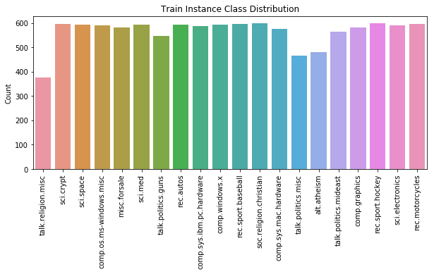

```python
fig = plt.figure(figsize = (10,4))
sns.countplot(x = train_class)
plt.xticks(rotation = 90)
plt.ylabel('Count')
plt.title('Train Instance Class Distribution')
```

```
Text(0.5,1,'Broader Topic Distribution')
```

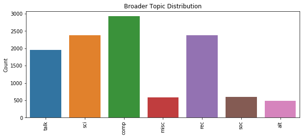

```python
train_class_broad_topics = [x.strip().split('.')[0] for x in train_class]
fig = plt.figure(figsize = (10,4))
sns.countplot(x = train_class_broad_topics)
plt.xticks(rotation = 90)
plt.ylabel('Count')
plt.title('Broader Topic Distribution')
```

## Text Feature Extraction Approaches

Mapping text data to numeric values useful for analysis and model development is a challenging task. A variety of approaches have been developed. A few of the more common techniques are explored below.

Due to the large size of the data set, we first create a smaller, class-balanced data set for illustrative purposes.

```python
# Downsample cases for faster computing/visualization
N_INSTANCES = 20
classes = np.unique(train_class)

downsample_inds = []
for each in classes:

    tmp_ind = list(np.where(train_class == each)[0][:N_INSTANCES])
    downsample_inds = downsample_inds + tmp_ind


small_train_text = train_text[downsample_inds]
small_train_class = train_class[downsample_inds]

print 'Number of classes:\t', len(classes)
print 'Number of instances:\t', len(downsample_inds)
```

```
Number of classes:	20
Number of instances:	400
```

### Word Counts

Word counts are the most straightforward means of converting a set of words into a numeric vector. Simply look at the set of words in the training set, and count the number of occurences for each instance. This same set of words will then be used to create feature vectors for any new examples (e.g. from a testing data set).

```python
# Compute word counts
cv = CountVectorizer()
cv_matrix = cv.fit_transform(small_train_text)


dense_matrix = cv_matrix.toarray()

# View
print 'Vocabulary size: ', dense_matrix.shape[1]
pd.DataFrame(dense_matrix[6:12,56:63], columns = cv.get_feature_names()[56:63])
```

```
Vocabulary size:  12255
```

|  | accomplish | accord | accordingli | account | accur | accuraci | accus |
| --- | --- | --- | --- | --- | --- | --- | --- |
| 0 | 0 | 0 | 0 | 0 | 0 | 0 | 0 |
| 1 | 0 | 1 | 0 | 0 | 1 | 0 | 0 |
| 2 | 0 | 1 | 0 | 0 | 0 | 0 | 0 |
| 3 | 0 | 2 | 0 | 0 | 0 | 0 | 0 |
| 4 | 0 | 1 | 0 | 0 | 0 | 0 | 0 |
| 5 | 0 | 0 | 0 | 0 | 0 | 0 | 0 |

It is important to note that the majority of words are *not* present in any given article. As such, word count representations tend to be very sparse and benefit from sparse matrix representations which compress the data and reduce memory footprint.

### N-grams

N-grams are sets of words that occur one after another for some length of sequence. The most common examples are word pairs, but this concept can generalize to any length sequence. Unlike word counts, n-grams help retain some of the context and spatial information about word order. However, this process results in a large increase in the feature space which further enhances the problem of hte "curse of dimensionality."

```python
# Compute bi-gram counts
ngram_cv = CountVectorizer(ngram_range = (2,2))
ngram_cv_matrix = ngram_cv.fit_transform(small_train_text)

# Conver to dense array for visualization
dense_matrix = ngram_cv_matrix.toarray()

# View
print 'Vocabulary size: ', dense_matrix.shape[1]
pd.DataFrame(dense_matrix[4:10, 2084:2090], columns = ngram_cv.get_feature_names()[2084:2090])
```

```
Vocabulary size:  55292
```

|  | anyway strip | anyway think | anyway took | anyway via | anyway would | anyway wrong |
| --- | --- | --- | --- | --- | --- | --- |
| 0 | 0 | 0 | 0 | 0 | 0 | 0 |
| 1 | 0 | 1 | 0 | 0 | 0 | 0 |
| 2 | 0 | 0 | 0 | 0 | 0 | 0 |
| 3 | 0 | 0 | 0 | 0 | 0 | 0 |
| 4 | 0 | 0 | 0 | 0 | 0 | 0 |
| 5 | 0 | 1 | 0 | 0 | 0 | 1 |

We now see that our column names are not a single word but pairs of words. Similar to count vectors, n-gram vectors are very sparse (even moreso since many word pairs may not even exist in language). While n-grams capture spatial and contextual information, their benefits may be limited in applications where text is very noisy since a large number of spurious, uninformative word pairs will be counted. For more targeted applications or pipelines with very refined preprocessing and filtering steps, n-grams may result in better performance than simple word counts.

### TF-IDF

TF-IDF is short-hand for the phrase "term frequency - inverse document frequency" which is a process that represents words as a frequency rather than a count. However, instead of just computing the frequency of word A in a text, we penalize that frequency by the occurence of that word across **all** other texts in the corpus. This results in a "regularized" representation of word counts that helps limit the influence of overly-abundant words that do not contribute unique or actionable information.

```python
# Compute tf-idf word representations
tv = TfidfVectorizer()
tv_matrix = tv.fit_transform(small_train_text)

# Conver to dense array for visualization
dense_matrix = tv_matrix.toarray()

# View
print 'Vocabulary size: ', dense_matrix.shape[1]
pd.DataFrame(dense_matrix[1:5,82:90], columns = tv.get_feature_names()[82:90])
```

```
Vocabulary size:  12255
```

|  | across | acsc | act | actaulli | action | activ | activa | actor |
| --- | --- | --- | --- | --- | --- | --- | --- | --- |
| 0 | 0.0 | 0.0 | 0.0 | 0.087783 | 0.000000 | 0.0 | 0.0 | 0.0 |
| 1 | 0.0 | 0.0 | 0.0 | 0.000000 | 0.000000 | 0.0 | 0.0 | 0.0 |
| 2 | 0.0 | 0.0 | 0.0 | 0.000000 | 0.035307 | 0.0 | 0.0 | 0.0 |
| 3 | 0.0 | 0.0 | 0.0 | 0.000000 | 0.100734 | 0.0 | 0.0 | 0.0 |

In the above dataframe we now see the float representations of word frequencies.

## Document Similarity (Unsupervised)

```python
# Instantiate object to vectorize word counts using TF-IDF model
tv = TfidfVectorizer(use_idf = True)

# Create sparse matrix containing vectorized word counts
tv_matrix = tv.fit_transform(train_text)

# View shape
print tv_matrix.shape
```

```
(11297, 66697)
```

```python
# Downsample cases for faster computing/visualization
N_INSTANCES = 20
classes = np.unique(train_class)

downsample_inds = []
for each in classes:

    tmp_ind = list(np.where(train_class == each)[0][:N_INSTANCES])
    downsample_inds = downsample_inds + tmp_ind


print 'Number of classes:\t', len(classes)
print 'Number of instances:\t', len(downsample_inds)
```

```
Number of classes:	20
Number of instances:	400
```

```python
# Compute cosine similarity on TF-IDF matrix
similarity_matrix = cosine_similarity(tv_matrix[downsample_inds,:])

# View
print 'Shape:\t', similarity_matrix.shape
similarity_matrix[1:5,1:5]
```

```
Shape:	(400L, 400L)
```

```
array([[1.        , 0.01343888, 0.0397241 , 0.02728751],
       [0.01343888, 1.        , 0.02138485, 0.02761552],
       [0.0397241 , 0.02138485, 1.        , 0.04826273],
       [0.02728751, 0.02761552, 0.04826273, 1.        ]])
```

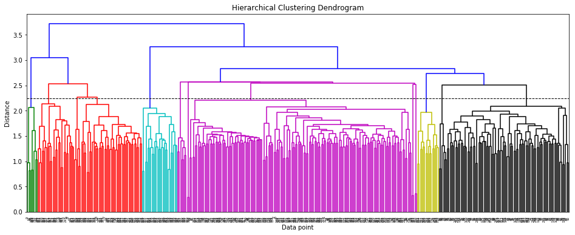

```python
# Cluster
Z = linkage(similarity_matrix, 'ward')

# View
plt.figure(figsize = (16, 6))
plt.title('Hierarchical Clustering Dendrogram')
plt.xlabel('Data point')
plt.ylabel('Distance')
dendrogram(Z)
plt.axhline(y = 2.25, c = 'k', ls = '--', lw = 1)
```

It seems that we have derived 6 clusters in our set where we actually have 20. However, if we look at the higher-level "topics" of our collection, we find the following seven:

- Alt
- Comp
- Misc
- Rec
- Sci
- Soc
- Talk

How well might these larger topics correlate with these derived clusters?

## Document Similarity (Semi-Supervised)

### Correlation between broader topics and unsupervised cluster assignment

```python
# Define clustering approach
h_clust = AgglomerativeClustering(n_clusters = 6, linkage = 'ward')

# Fit and extract cluster labels
cluster_labels = h_clust.fit_predict(tv_matrix[downsample_inds,:].toarray())
```

```
Text(0.5,1,'Cluster Membership Distribution')
```

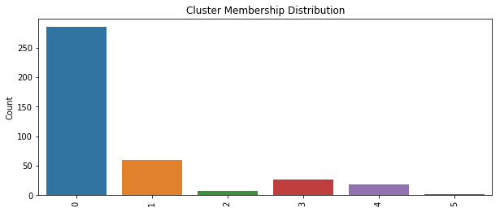

```python
fig = plt.figure(figsize = (10,4))
sns.countplot(x = cluster_labels)
plt.xticks(rotation = 90)
plt.ylabel('Count')
plt.title('Cluster Membership Distribution')
```

Seems that most of the instances are being assigned to a single cluster (0) which represents the "ungrouped" items. How does the distribution of true class labels look in each cluster? Can a specific cluster "label" be assigned given the class frequencies?

```python
clust_dict = dict()

# Iterate over clusters
for clust in range(0,6):

    # Extract indices for each cluster
    tmp_inds = np.where(cluster_labels == clust)[0]

    # Pull class labels for instances in cluster
    tmp_labels = train_class[downsample_inds][tmp_inds]

    # Save to dict for plotting
    clust_dict[clust] = tmp_labels
```

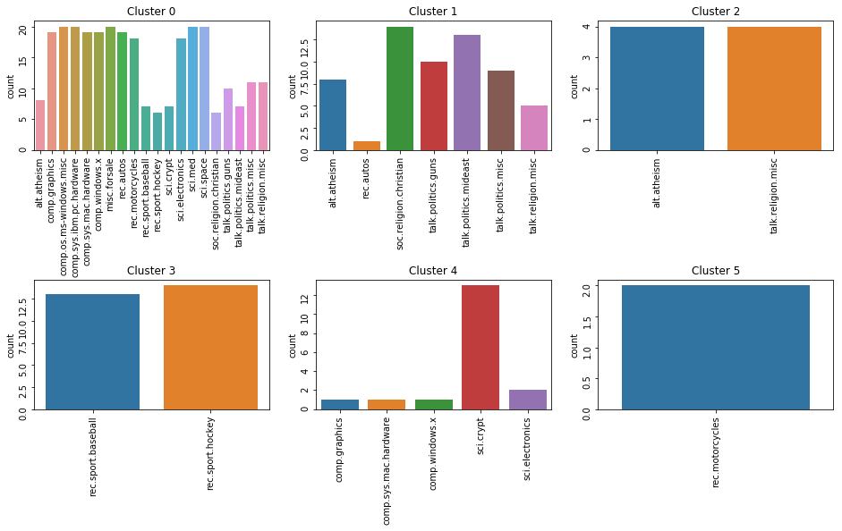

```python
# All topics
fig, ax = plt.subplots(nrows = 2, ncols = 3, figsize = (16,8))
ax = ax.flatten()

for i in range(0,6):
    sns.countplot(x = clust_dict[i], ax = ax[i])
    ax[i].tick_params(labelrotation=90)
    ax[i].set_title('Cluster ' + str(i))

plt.subplots_adjust(hspace = 1)
```

Cluster "zero", the catch-all cluster, does indeed seem to contain a variety of topics. Some clusters such as "two" and "three" contain entries of certain topics (religion and sports, respectively). Cluster "one" largely contains talk-related domains while cluster "four" has examples from a variety of computer-related topics. Unlike the other clusters, cluster "five" contains only two instances from a single topic: motorcycles.

It is unfortunate that the majority of articles across almost all domains were tossed into cluster "zero" suggesting that additional filtering is required to better summarize. However, it is also important to remember that we are forcing the existence of six clusters, which is not the *optimal* or *true* number of topics and may bias the cluster assignment.

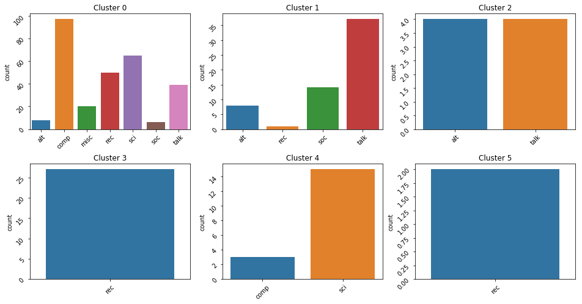

```python
# Broader topics
fig, ax = plt.subplots(nrows = 2, ncols = 3, figsize = (16,8))
ax = ax.flatten()

for i in range(0,6):
    sns.countplot(x = [x.split('.')[0] for x in clust_dict[i]], ax = ax[i])
    ax[i].tick_params(labelrotation=45)
    ax[i].set_title('Cluster ' + str(i))

plt.subplots_adjust(hspace = 0.3)
```

Similar to above, when looking at the broader article topics, we see patterns of topic distribution across the clusters that do not necessarily reflect the expected topic groups.

### Principle Component Document Representation

For very wide data it can be beneficial to perform some dimensionality reduction to reduce the total number of features while maximizing the variance that is retained. Below is an illustration of applying PCA to the TF-IDF matrix and reducing the data set to only 30 features (i.e. principle components).

We then re-cluster these samples, inspect the resulting patterns, and project some of the principle components to visualize the distribution of classes along those axes.

```python
le = LabelEncoder()
train_labels = le.fit_transform(train_class)
```

```python
# Create non-sparse array for manipulation (PCA does not work with sparse arrays)
tv_matrix_dense = tv_matrix[downsample_inds, :].toarray()

# Perform PCA
pca = PCA(n_components = 30)
pca.fit(tv_matrix_dense)

# Compute the reduced matrix
tv_reduced = pca.transform(tv_matrix_dense)
```

Let's look at the first two principle components and see what structure may exist that helps separate instances.

```
Text(0,0.5,'PC2')
```

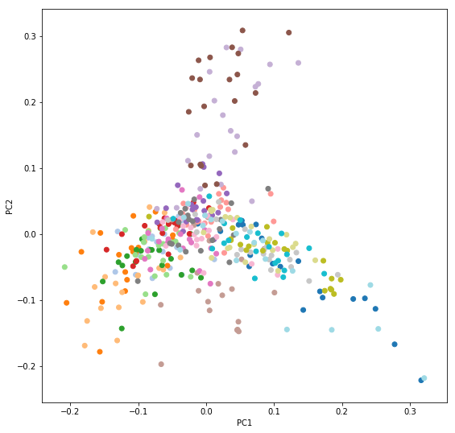

```python
plt.figure(figsize = (9,9))
plt.scatter(tv_reduced[:,0], tv_reduced[:,1], c = train_labels[downsample_inds], cmap = plt.cm.tab20)
plt.xlabel('PC1')
plt.ylabel('PC2')
```

There seems to be a strong signal in the first two dimensions projecting the documnets into roughly three overlapping groups. Let's look at a few more PCs and their pair-wise interactions...

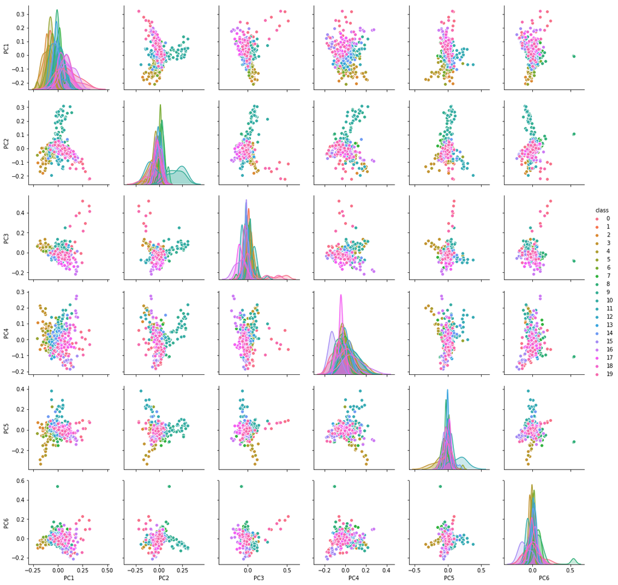

```python
# Convert to dataframe for seaborn
pc_df = pd.DataFrame(tv_reduced, columns = ['PC' + str(i) for i in range(1,31)])
pc_df['class'] = train_labels[downsample_inds]
pc_df['label'] = train_class[downsample_inds]

# Plot
sns.pairplot(data = pc_df,
             hue = 'class',
             vars = ['PC' + str(i) for i in range(1,7)])
```

Varying degrees of overlap exist across the document classes. It is difficult to discern much structure beyond the first few principle components. Let's see what we find by running the same clustering procedure as before but on our reduced data set.

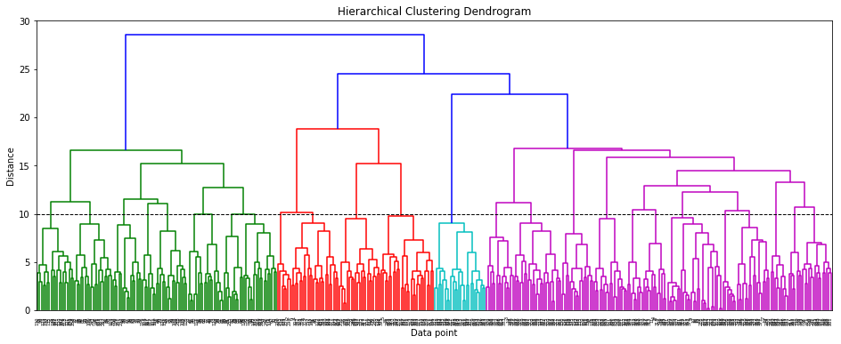

```python
# Compute cosine similarity on PCs
similarity_matrix = cosine_similarity(tv_reduced)

# Cluster
Z = linkage(similarity_matrix, 'ward')

# View
plt.figure(figsize = (16, 6))
plt.title('Hierarchical Clustering Dendrogram')
plt.xlabel('Data point')
plt.ylabel('Distance')
dendrogram(Z)
plt.axhline(y = 10, c = 'k', ls = '--', lw = 1)
```

With reduced information (we are only using the first 30 principle components derived from roughly 60k features), the articles appear more similar to each other overall which reduces the total number of clusters. For comparability, we will repeat our analysis of the terms in each clustering with N = 6 clusters.

```python
# Define clustering approach
h_clust = AgglomerativeClustering(n_clusters = 6, linkage = 'ward')

# Fit and extract cluster labels
cluster_labels = h_clust.fit_predict(tv_reduced)
```

```
Text(0.5,1,'Cluster Membership Distribution')
```

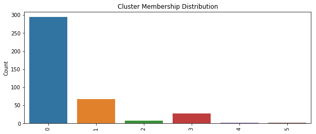

```python
fig = plt.figure(figsize = (10,4))
sns.countplot(x = cluster_labels)
plt.xticks(rotation = 90)
plt.ylabel('Count')
plt.title('Cluster Membership Distribution')
```

More individuals have been placed in cluster "zero" suggesting that by reducing the dimensionality of our data we may have lost some important information for distinguishing between article types.

```python
clust_dict = dict()

# Iterate over clusters
for clust in range(0,6):

    # Extract indices for each cluster
    tmp_inds = np.where(cluster_labels == clust)[0]

    # Pull class labels for instances in cluster
    tmp_labels = train_class[downsample_inds][tmp_inds]

    # Save to dict for plotting
    clust_dict[clust] = tmp_labels
```

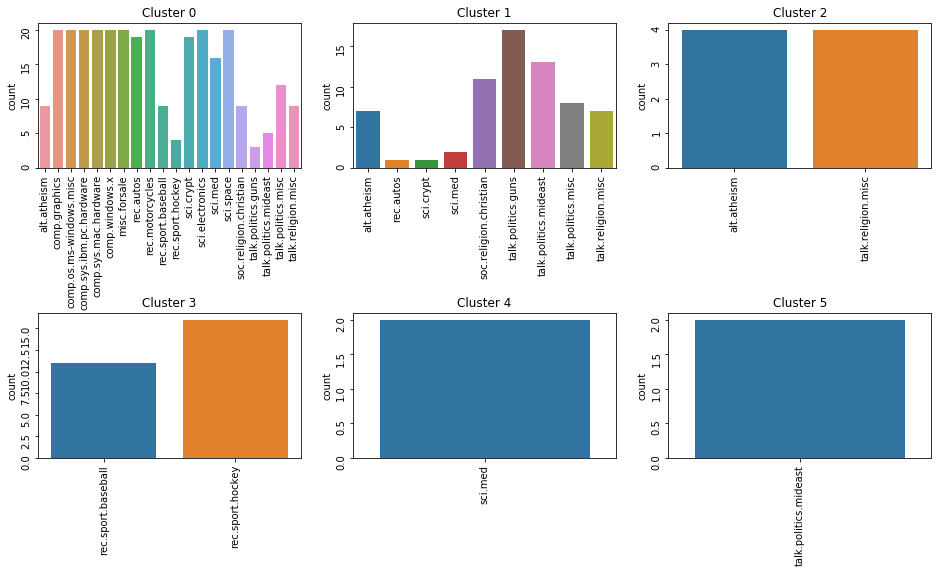

```python
# All topics
fig, ax = plt.subplots(nrows = 2, ncols = 3, figsize = (16,8))
ax = ax.flatten()

for i in range(0,6):
    sns.countplot(x = clust_dict[i], ax = ax[i])
    ax[i].tick_params(labelrotation=90)
    ax[i].set_title('Cluster ' + str(i))

plt.subplots_adjust(hspace = 1)
```

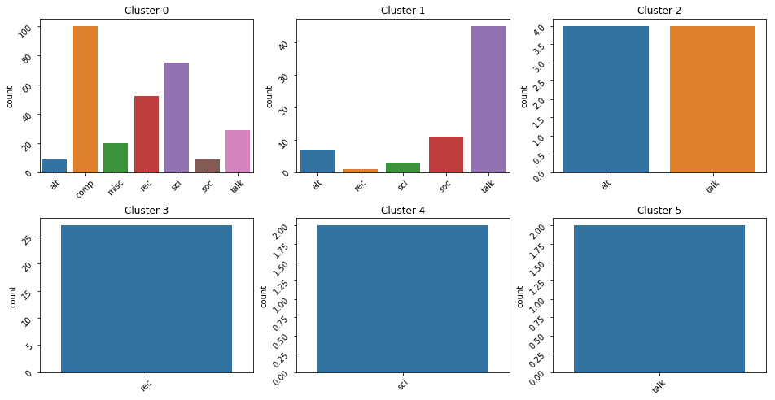

```python
# Broader topics
fig, ax = plt.subplots(nrows = 2, ncols = 3, figsize = (16,8))
ax = ax.flatten()

for i in range(0,6):
    sns.countplot(x = [x.split('.')[0] for x in clust_dict[i]], ax = ax[i])
    ax[i].tick_params(labelrotation=45)
    ax[i].set_title('Cluster ' + str(i))

plt.subplots_adjust(hspace = 0.3)
```

This may be in part tied to the dimensionality reduction but may also be an artifact of noise. Such relationships are difficult to assess; nonetheless it is nice to see that the majority of the structure within the data was retained following PCA.

## Document Classification (Supervised)

Moving beyond simple exploration, we will illustrate the development of models for document classification and highlight the effect of some important decisions.

We will make use of the Naive Bayes classifier which is a simple but efficent method of classification which utilizes Bayes theorem. It has long been used in the field of text classification/retrieval and today is used as a baseline standard for evaluating algorithm performance.

```python
# Convert class labels to integers required by the algorithms
le = LabelEncoder()
train_labels = le.fit_transform(train_class)
test_labels = le.transform(test_class)
```

```python
# Instantiate object to vectorize word counts
cv = CountVectorizer()

# Create sparse matrix containing vectorized word counts
cv_train_matrix = cv.fit_transform(train_text)
cv_test_matrix = cv.transform(test_text)

# View shapes
print 'Train: ', cv_train_matrix.shape
print 'Test:  ', cv_test_matrix.shape
```

```
Train:  (11297, 66697)
Test:   (7515, 66697)
```

```python
# Instantiate object to vectorize word counts using TF-IDF model
tv = TfidfVectorizer(use_idf = True)

# Create sparse matrix containing vectorized word counts
tv_train_matrix = tv.fit_transform(train_text)
tv_test_matrix = tv.transform(test_text)

# View shapes
print 'Train: ', tv_train_matrix.shape
print 'Test:  ', tv_test_matrix.shape
```

```
Train:  (11297, 66697)
Test:   (7515, 66697)
```

### Comparison of Count vs. TF-IDF Feature Representations (Multinomial NB)

```python
# Instantiate classifiers
cv_nb_clf = MultinomialNB(alpha = 1, fit_prior = True)
tv_nb_clf = MultinomialNB(alpha = 1, fit_prior = True)

# Fit classifiers
cv_nb_clf.fit(cv_train_matrix, train_labels)
tv_nb_clf.fit(tv_train_matrix, train_labels)

# Get predictions
cv_train_preds = cv_nb_clf.predict(cv_train_matrix)
tv_train_preds = tv_nb_clf.predict(tv_train_matrix)
cv_test_preds = cv_nb_clf.predict(cv_test_matrix)
tv_test_preds = tv_nb_clf.predict(tv_test_matrix)
```

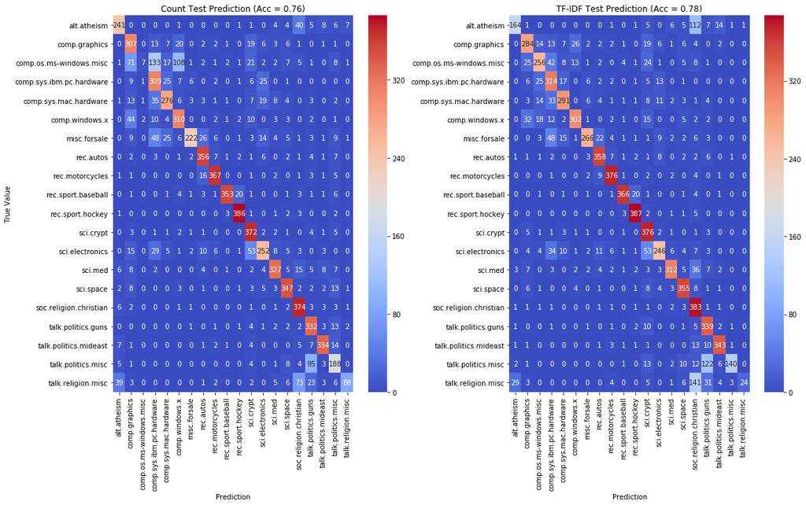

```python
# Compute confusion matrix
cv_cm = confusion_matrix(test_labels, cv_test_preds)
tv_cm = confusion_matrix(test_labels, tv_test_preds)

# Re-format for plotting
cv_cm = pd.DataFrame(cv_cm,
                     index = le.inverse_transform(np.unique(test_labels)),
                     columns = le.inverse_transform(np.unique(test_labels)))

tv_cm = pd.DataFrame(tv_cm,
                     index = le.inverse_transform(np.unique(test_labels)),
                     columns = le.inverse_transform(np.unique(test_labels)))

count_acc = accuracy_score(test_labels, cv_test_preds)
tf_idf_acc = accuracy_score(test_labels, tv_test_preds)

# Plot heatmap
fig, ax = plt.subplots(1,2, figsize = (18,10))
sns.heatmap(cv_cm, annot = True, fmt = 'd', cmap = 'coolwarm', ax = ax[0])
ax[0].set_title('Count Test Prediction (Acc = %0.2f)' % count_acc)
ax[0].set_xlabel('Prediction')
ax[0].set_ylabel('True Value')

sns.heatmap(tv_cm, annot = True, fmt = 'd', cmap = 'coolwarm', ax = ax[1])
ax[1].set_title('TF-IDF Test Prediction (Acc = %0.2f)' % tf_idf_acc)
ax[1].set_xlabel('Prediction')

plt.subplots_adjust(wspace = 0.32)
```

We see that the TF-IDF feature representation leads to a slightly higher overall classification accuracy. However, it is interesting to note that the *challening* examples fo rhte classifier change with the feature representation.

For instance, the count features seem to better capture information for classifying "alt.atheism" documnets than the TF-IDF features. However, count and TF-IDF features seem equally sufficient for capturing the information useful for classifying recreational ("rec") documents.

### Comparison of ComplementNB and MultinomialNB (using count data)

```python
# Instantiate classifiers
multi_nb_clf = MultinomialNB(alpha = 1, fit_prior = True)
comp_nb_clf = ComplementNB(alpha = 1, fit_prior = True)

# Fit classifiers
multi_nb_clf.fit(cv_train_matrix, train_labels)
comp_nb_clf.fit(cv_train_matrix, train_labels)

# Get predictions
multi_train_preds = multi_nb_clf.predict(cv_train_matrix)
multi_test_preds = multi_nb_clf.predict(cv_test_matrix)

comp_train_preds = comp_nb_clf.predict(cv_train_matrix)
comp_test_preds = comp_nb_clf.predict(cv_test_matrix)
```

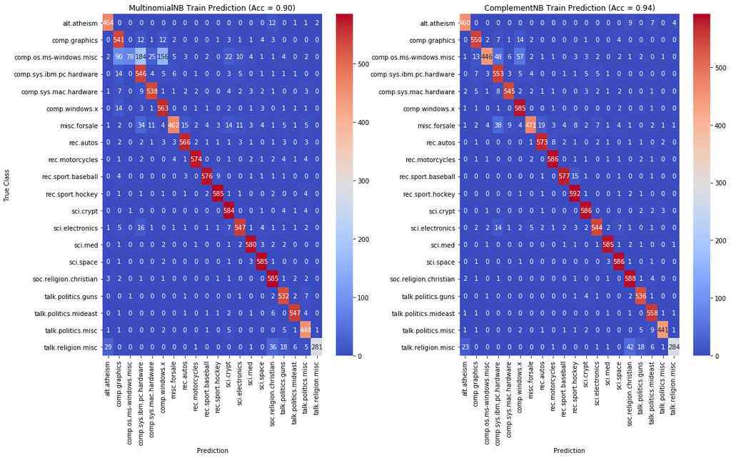

```python
# Compute training data confusion matrices for insight into model fit
multi_cm = confusion_matrix(train_labels, multi_train_preds)
comp_cm = confusion_matrix(train_labels, comp_train_preds)

# Reformat for plotting
multi_cm = pd.DataFrame(multi_cm,
                        index = le.inverse_transform(np.unique(train_labels)),
                        columns = le.inverse_transform(np.unique(train_labels)))

comp_cm = pd.DataFrame(comp_cm,
                       index = le.inverse_transform(np.unique(train_labels)),
                       columns = le.inverse_transform(np.unique(train_labels)))

# Compute overall accuracies
multi_acc = accuracy_score(train_labels, multi_train_preds)
comp_acc = accuracy_score(train_labels, comp_train_preds)

# Plot heatmaps
fig, ax = plt.subplots(1,2, figsize = (18,10))
sns.heatmap(multi_cm, annot = True, fmt = 'd', cmap = 'coolwarm', ax = ax[0])
ax[0].set_title('MultinomialNB Train Prediction (Acc = %0.2f)' % multi_acc)
ax[0].set_xlabel('Prediction')
ax[0].set_ylabel('True Class')

sns.heatmap(comp_cm, annot = True, fmt = 'd', cmap = 'coolwarm', ax = ax[1])
ax[1].set_title('ComplementNB Train Prediction (Acc = %0.2f)' % comp_acc)
ax[1].set_xlabel('Prediction')

plt.subplots_adjust(wspace = 0.3)
```

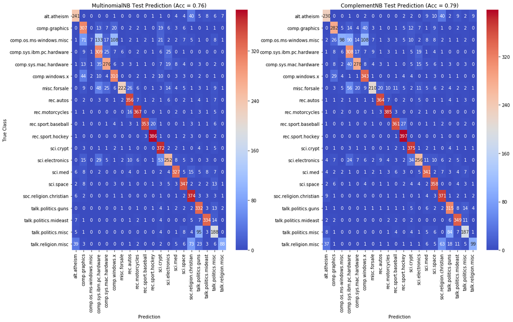

```python
# Compute testing data confusion matrices for insight into model fit
multi_cm = confusion_matrix(test_labels, multi_test_preds)
comp_cm = confusion_matrix(test_labels, comp_test_preds)

# Reformat for plotting
multi_cm = pd.DataFrame(multi_cm,
                        index = le.inverse_transform(np.unique(test_labels)),
                        columns = le.inverse_transform(np.unique(test_labels)))

comp_cm = pd.DataFrame(comp_cm,
                       index = le.inverse_transform(np.unique(test_labels)),
                       columns = le.inverse_transform(np.unique(test_labels)))

# Compute overall accuracies
multi_acc = accuracy_score(test_labels, multi_test_preds)
comp_acc = accuracy_score(test_labels, comp_test_preds)

# Plot heatmaps
fig, ax = plt.subplots(1,2, figsize = (18,10))
sns.heatmap(multi_cm, annot = True, fmt = 'd', cmap = 'coolwarm', ax = ax[0])
ax[0].set_title('MultinomialNB Test Prediction (Acc = %0.2f)' % multi_acc)
ax[0].set_xlabel('Prediction')
ax[0].set_ylabel('True Class')

sns.heatmap(comp_cm, annot = True, fmt = 'd', cmap = 'coolwarm', ax = ax[1])
ax[1].set_title('ComplementNB Test Prediction (Acc = %0.2f)' % comp_acc)
ax[1].set_xlabel('Prediction')

plt.subplots_adjust(wspace = 0.3)
```

On both the training and testing data sets we see that Complement NB performs slightly better than using the methodologies of multinomial NB. Again, it is difficult to derive insignt into *why* this is the case. I defer to the authors of the Complement Naive Bayes algorithm whose [paper](https://www.aaai.org/Papers/ICML/2003/ICML03-081.pdf) highlights some of the benefits over the traditional approach.